# Temporal-Difference Methods

In this notebook, you will write your own implementations of many Temporal-Difference (TD) methods.

While we have provided some starter code, you are welcome to erase these hints and write your code from scratch.

### Part 0: Explore CliffWalkingEnv

We begin by importing the necessary packages.

```python
%config Completer.use_jedi = False
```

```python
import sys
import gym
import numpy as np
from collections import defaultdict, deque
import matplotlib.pyplot as plt
%matplotlib inline

import check_test
from plot_utils import plot_values
```

Use the code cell below to create an instance of the [CliffWalking](https://github.com/openai/gym/blob/master/gym/envs/toy_text/cliffwalking.py) environment.

```python
env = gym.make('CliffWalking-v0')
```

The agent moves through a $4\times 12$ gridworld, with states numbered as follows:

```
[[ 0,  1,  2,  3,  4,  5,  6,  7,  8,  9, 10, 11],
 [12, 13, 14, 15, 16, 17, 18, 19, 20, 21, 22, 23],
 [24, 25, 26, 27, 28, 29, 30, 31, 32, 33, 34, 35],
 [36, 37, 38, 39, 40, 41, 42, 43, 44, 45, 46, 47]]
```

At the start of any episode, state `36` is the initial state. State `47` is the only terminal state, and the cliff corresponds to states `37` through `46`.

The agent has 4 potential actions:

```
UP = 0
RIGHT = 1
DOWN = 2
LEFT = 3
```

Thus, $\mathcal{S}^+=\{0, 1, \ldots, 47\}$, and $\mathcal{A} =\{0, 1, 2, 3\}$. Verify this by running the code cell below.

```python
print(env.action_space)
print(env.observation_space)
```

```
Discrete(4)
Discrete(48)
```

In this mini-project, we will build towards finding the optimal policy for the CliffWalking environment. The optimal state-value function is visualized below. Please take the time now to make sure that you understand *why* this is the optimal state-value function.

**Note**: You can safely ignore the values of the cliff "states" as these are not true states from which the agent can make decisions. For the cliff "states", the state-value function is not well-defined.

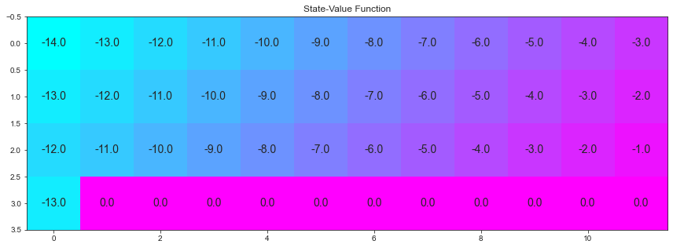

```python
# define the optimal state-value function
V_opt = np.zeros((4,12))
V_opt[0:13][0] = -np.arange(3, 15)[::-1]
V_opt[0:13][1] = -np.arange(3, 15)[::-1] + 1
V_opt[0:13][2] = -np.arange(3, 15)[::-1] + 2
V_opt[3][0] = -13

plot_values(V_opt)
```

### Part 1: TD Control: Sarsa

In this section, you will write your own implementation of the Sarsa control algorithm.

The algorithm returns as output:

- `Q`: This is a dictionary (of one-dimensional arrays) where `Q[s][a]` is the estimated action value corresponding to state `s` and action `a`.

Please complete the function in the code cell below.

(*Feel free to define additional functions to help you to organize your code.*)

```python
import random
```

```python
def update_policy(state,Q,policy):
    k=max(Q[state]) #maximum value
    indices=[j for j in range(len(Q[state])) if  Q[state][j] == k] #Get all indices where the Q[index]= maximum value
    policy[state]=np.random.choice(indices) if len(indices)>1 else indices[0]
```

```python
def get_action(state, policy,epsilon):
    if state in policy and random.random()>epsilon:
        return policy[state]
    else:
        return random.choice(np.arange(env.action_space.n))
```

```python
def get_sarsa(state, action, next_state,next_value,alpha, gamma,Q,reward,done):
    if not done:
        q= Q[state][action]+alpha*(reward+gamma*(Q[next_state][next_value])-Q[state][action])
    else:
        q= Q[state][action]+alpha*(reward+gamma*0-Q[state][action])
    return q
```

```python
def sarsa(env, num_episodes, alpha, gamma=0.9,epsilon=5,drop=0.995,epsilon_min=0.005): #drop of 0.985 gives perfect results for 1st 2 rows
    # initialize action-value function (empty dictionary of arrays)
    Q=defaultdict(lambda: np.zeros(env.action_space.n))
    policy=defaultdict(lambda: 0)
    # initialize performance monitor
    J=[]
    total_reward=[]
    epsilon_val=[]
    for i in range(num_episodes):
        j=0
        rew=0
        state=env.reset()
        action=get_action(state,policy, epsilon)
        if i%100==0:
            print("\rEpisode {}/{}".format(i, num_episodes), end="")
            sys.stdout.flush()
        while True: # for each timestep of the episode
            next_state,reward,done,info=env.step(action)
            rew+=reward
            next_action=get_action(next_state,policy, epsilon)
            Q[state][action]=get_sarsa(state, action, next_state, next_action,alpha, gamma,Q,reward,done)
            update_policy(state,Q,policy)
            j+=1
            if done:
                break
            else:
                state=next_state
                action=next_action
        epsilon_val.append(epsilon)
        J.append(j)
        total_reward.append(rew)
        epsilon=1/(i+1)
    return (Q , J , total_reward, policy , num_episodes,epsilon_val)
```

Use the next code cell to visualize the *estimated* optimal policy and the corresponding state-value function.

```python
pol=np.hstack((np.ones(11), 2, 0))
pol
```

```
array([1., 1., 1., 1., 1., 1., 1., 1., 1., 1., 1., 2., 0.])
```

```
Episode 4900/5000
Estimated Optimal Policy (UP = 0, RIGHT = 1, DOWN = 2, LEFT = 3, N/A = -1):
[[ 1  3  1  1  1  1  1  2  2  1  1  2]
 [ 0  1  1  1  1  1  1  1  2  2  1  2]
 [ 0  0  0  1  1  1  1  1  1  1  1  2]
 [ 0 -1 -1 -1 -1 -1 -1 -1 -1 -1 -1 -1]]
```

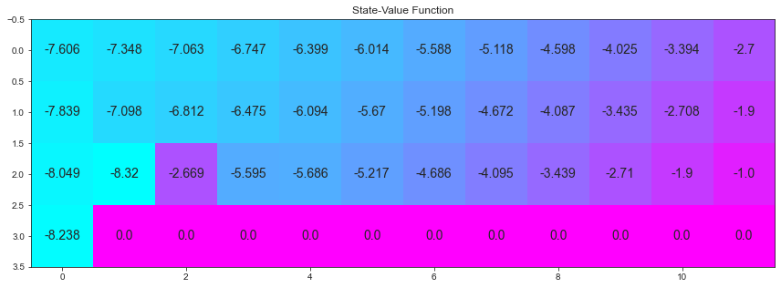

```
Estimated Optimal Policy (UP = 0, RIGHT = 1, DOWN = 2, LEFT = 3, N/A = -1):
[[ 0  1  1  1  2  2  1  2  1  2  0  2]
 [ 1  1  1  1  2  1  1  1  1  2  1  2]
 [ 0  0  0  1  1  1  1  1  1  1  1  2]
 [ 0 -1 -1 -1 -1 -1 -1 -1 -1 -1 -1 -1]]
```

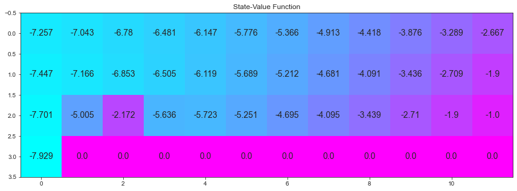

```
Estimated Optimal Policy (UP = 0, RIGHT = 1, DOWN = 2, LEFT = 3, N/A = -1):
[[ 2  1  1  1  2  1  1  1  0  2  2  3]
 [ 1  1  1  1  1  1  1  2  2  1  2  2]
 [ 1  1  1  1  1  1  1  1  1  1  1  2]
 [ 0 -1 -1 -1 -1 -1 -1 -1 -1 -1 -1 -1]]
```

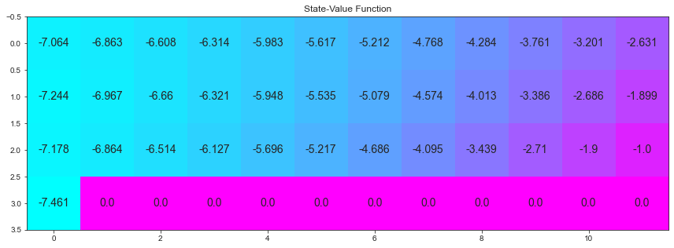

```
Estimated Optimal Policy (UP = 0, RIGHT = 1, DOWN = 2, LEFT = 3, N/A = -1):
[[ 1  1  1  2  1  1  1  1  2  2  2  2]
 [ 0  0  0  1  1  1  1  1  1  1  1  2]
 [ 0  0  0  0  0  1  1  1  1  1  1  2]
 [ 0 -1 -1 -1 -1 -1 -1 -1 -1 -1 -1 -1]]
```

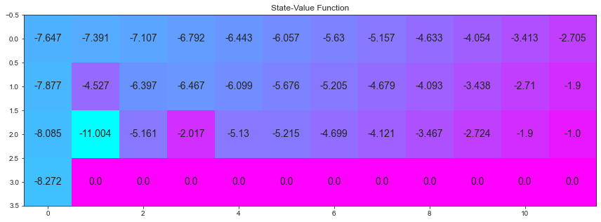

```
Estimated Optimal Policy (UP = 0, RIGHT = 1, DOWN = 2, LEFT = 3, N/A = -1):
[[ 1  1  1  1  1  1  1  1  2  2  2  2]
 [ 0  0  0  1  1  1  1  1  2  1  2  2]
 [ 0  0  0  0  1  1  1  1  1  1  1  2]
 [ 0 -1 -1 -1 -1 -1 -1 -1 -1 -1 -1 -1]]
```

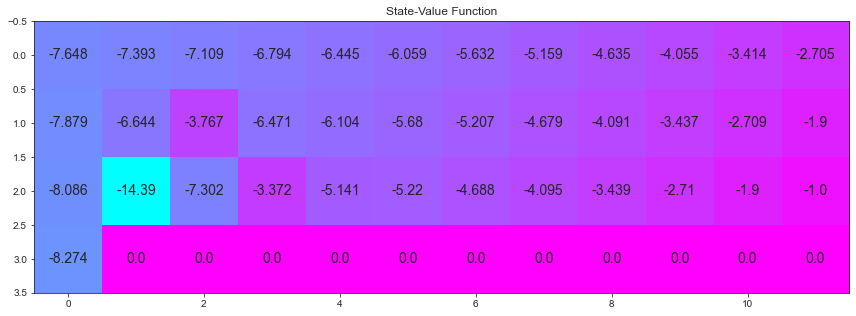

```
Estimated Optimal Policy (UP = 0, RIGHT = 1, DOWN = 2, LEFT = 3, N/A = -1):
[[ 1  2  1  3  1  1  1  0  2  1  2  2]
 [ 1  1  1  1  1  2  2  1  1  1  2  2]
 [ 0  0  0  1  1  1  1  1  1  1  1  2]
 [ 0 -1 -1 -1 -1 -1 -1 -1 -1 -1 -1 -1]]
```

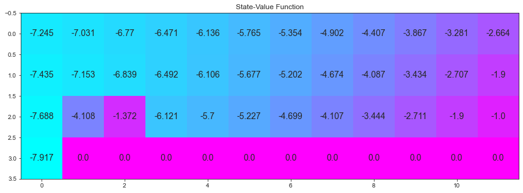

```
Estimated Optimal Policy (UP = 0, RIGHT = 1, DOWN = 2, LEFT = 3, N/A = -1):
[[ 1  1  1  1  2  1  1  1  1  1  1  2]
 [ 0  0  0  0  1  1  1  1  1  1  2  2]
 [ 0  0  0  0  0  0  1  1  1  1  1  2]
 [ 0 -1 -1 -1 -1 -1 -1 -1 -1 -1 -1 -1]]
```

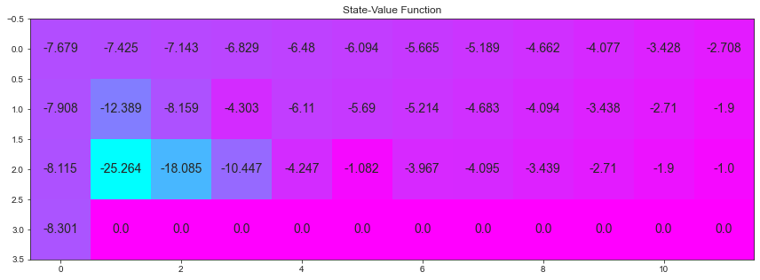

```
Estimated Optimal Policy (UP = 0, RIGHT = 1, DOWN = 2, LEFT = 3, N/A = -1):
[[ 1  1  1  1  1  1  1  1  1  1  1  2]
 [ 1  1  1  1  1  2  1  1  1  1  2  2]
 [ 0  0  0  1  1  1  1  1  1  1  1  2]
 [ 0 -1 -1 -1 -1 -1 -1 -1 -1 -1 -1 -1]]
```

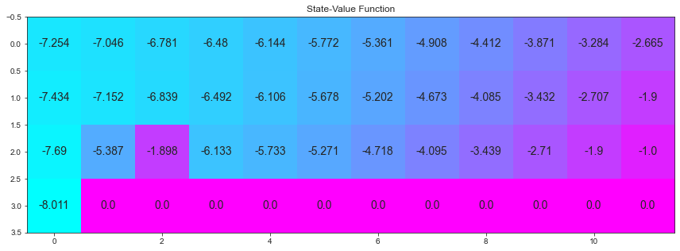

```
Estimated Optimal Policy (UP = 0, RIGHT = 1, DOWN = 2, LEFT = 3, N/A = -1):
[[ 1  1  1  1  1  1  1  1  2  2  2  3]
 [ 1  1  1  1  1  1  1  2  1  1  2  2]
 [ 0  0  0  1  1  1  1  1  1  1  1  2]
 [ 0 -1 -1 -1 -1 -1 -1 -1 -1 -1 -1 -1]]
```

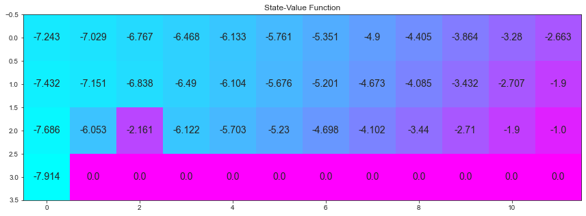

```
Estimated Optimal Policy (UP = 0, RIGHT = 1, DOWN = 2, LEFT = 3, N/A = -1):
[[ 0  1  1  1  3  1  1  2  1  1  1  2]
 [ 1  1  1  2  1  2  1  2  1  2  2  2]
 [ 0  0  1  1  1  1  1  1  1  1  1  2]
 [ 0 -1 -1 -1 -1 -1 -1 -1 -1 -1 -1 -1]]
```

```python
# obtain the estimated optimal policy and corresponding action-value function
attempts_sarsa=[]
for _ in range(10):
    Q_sarsa, J_sarsa, total_reward,policy, n_epsiodes,sarsa_epsilon_val = sarsa(env, 5000, .01)
    attempts_sarsa.append((Q_sarsa, J_sarsa, total_reward,policy, n_epsiodes))

# print the estimated optimal policy
for a in attempts_sarsa:
    Q_sarsa=a[0]
    policy_sarsa = np.array([np.argmax(Q_sarsa[key]) if key in Q_sarsa else -1 for key in np.arange(48)]).reshape(4,12)
    print("\nEstimated Optimal Policy (UP = 0, RIGHT = 1, DOWN = 2, LEFT = 3, N/A = -1):")
    print(policy_sarsa)

    # plot the estimated optimal state-value function
    V_sarsa = ([np.max(Q_sarsa[key]) if key in Q_sarsa else 0 for key in np.arange(48)])
    plot_values(V_sarsa)
```

[output not shown]

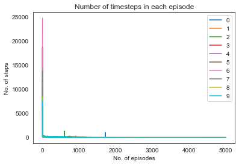

```python
for i in range(len(attempts_sarsa)):
    steps_arr=attempts_sarsa[i][1]
    n_episodes=attempts_sarsa[i][4]
    plt.plot(range(5000),steps_arr)
    plt.xlabel('No. of episodes')
    plt.ylabel('No. of steps')
    plt.title('Number of timesteps in each episode')
    plt.legend(np.arange(i+1))
plt.show()
```

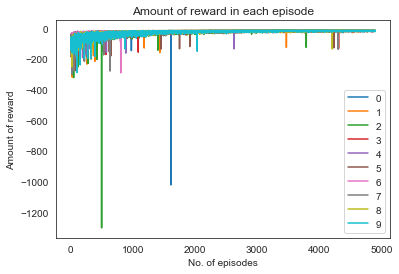

```python
for i in range(len(attempts_sarsa)):
    reward=attempts_sarsa[i][2]
    n_episodes=attempts_sarsa[i][4]
    plt.plot(range(4900),reward[100:])
    plt.xlabel('No. of episodes')
    plt.ylabel('Amount of reward')
    plt.title('Amount of reward in each episode')
    plt.legend(np.arange(i+1))
plt.show()
```

### Part 2: TD Control: Q-learning

In this section, you will write your own implementation of the Q-learning control algorithm.

Your algorithm has four arguments:

- `env`: This is an instance of an OpenAI Gym environment.
- `num_episodes`: This is the number of episodes that are generated through agent-environment interaction.
- `alpha`: This is the step-size parameter for the update step.
- `gamma`: This is the discount rate. It must be a value between 0 and 1, inclusive (default value: `1`).

The algorithm returns as output:

- `Q`: This is a dictionary (of one-dimensional arrays) where `Q[s][a]` is the estimated action value corresponding to state `s` and action `a`.

Please complete the function in the code cell below.

(*Feel free to define additional functions to help you to organize your code.*)

```python
def get_q_learning(state, action, next_state, reward, alpha, gamma, done,Q):
    if done:
        q= Q[state][action]+alpha*(reward+ 0 - Q[state][action])
    else:
        q = Q[state][action]+alpha*(reward+gamma*max(Q[next_state]) - Q[state][action])
    return q
```

```python
def q_learning(env, num_episodes, alpha, gamma=1.0,epsilon=1):
    Q=defaultdict(lambda:np.zeros(env.action_space.n))
    policy=defaultdict(lambda:0)
    J=[]
    total_reward=[]
    epsilon_val=[]
    for i in range(num_episodes):
        j=0
        rew=0
        state=env.reset()
        action=get_action(state, policy,epsilon)
        if i%100==0:
            print("\rEpisode {}/{}".format(i, num_episodes), end="")
            sys.stdout.flush()
        epsilon=1/(0.6+i)
        while True:
            next_state, reward, done, info = env.step(action)
            rew+=reward
            Q[state][action]=get_q_learning(state, action, next_state, reward, alpha, gamma, done,Q)
            update_policy(state,Q,policy)
            j+=1
            if done:
                break
            else:
                next_action=get_action(next_state, policy,epsilon)
                state=next_state
                action=next_action
        epsilon_val.append(epsilon)
        total_reward.append(rew)
        J.append(j)
    return (Q,J,total_reward, policy, num_episodes, epsilon_val)
```

Use the next code cell to visualize the *estimated* optimal policy and the corresponding state-value function.

```python
attempts_sarsamax=[]
for _ in range(10):
    Q_sarsamax, J_sarsa, total_reward,policy, n_epsiodes, epsilon_val = q_learning(env, 5000, .01)
    attempts_sarsamax.append((Q_sarsamax, J_sarsa, total_reward,policy, n_epsiodes))

# print the estimated optimal policy
for a in attempts_sarsamax:
    Q_sarsamax=a[0]
    policy_sarsa = np.array([np.argmax(Q_sarsa[key]) if key in Q_sarsa else -1 for key in np.arange(48)]).reshape(4,12)
    print("\nEstimated Optimal Policy (UP = 0, RIGHT = 1, DOWN = 2, LEFT = 3, N/A = -1):")
    print(policy_sarsa)

    # plot the estimated optimal state-value function
    V_sarsa = ([np.max(Q_sarsa[key]) if key in Q_sarsa else 0 for key in np.arange(48)])
    plot_values(V_sarsa)
```

[output not shown]

```
Episode 4900/5000
Estimated Optimal Policy (UP = 0, RIGHT = 1, DOWN = 2, LEFT = 3, N/A = -1):
[[ 0  1  1  1  3  1  1  2  1  1  1  2]
 [ 1  1  1  2  1  2  1  2  1  2  2  2]
 [ 0  0  1  1  1  1  1  1  1  1  1  2]
 [ 0 -1 -1 -1 -1 -1 -1 -1 -1 -1 -1 -1]]
```

```
Estimated Optimal Policy (UP = 0, RIGHT = 1, DOWN = 2, LEFT = 3, N/A = -1):
[[ 0  1  1  1  3  1  1  2  1  1  1  2]
 [ 1  1  1  2  1  2  1  2  1  2  2  2]
 [ 0  0  1  1  1  1  1  1  1  1  1  2]
 [ 0 -1 -1 -1 -1 -1 -1 -1 -1 -1 -1 -1]]
```

```
Estimated Optimal Policy (UP = 0, RIGHT = 1, DOWN = 2, LEFT = 3, N/A = -1):
[[ 0  1  1  1  3  1  1  2  1  1  1  2]
 [ 1  1  1  2  1  2  1  2  1  2  2  2]
 [ 0  0  1  1  1  1  1  1  1  1  1  2]
 [ 0 -1 -1 -1 -1 -1 -1 -1 -1 -1 -1 -1]]
```

```
Estimated Optimal Policy (UP = 0, RIGHT = 1, DOWN = 2, LEFT = 3, N/A = -1):
[[ 0  1  1  1  3  1  1  2  1  1  1  2]
 [ 1  1  1  2  1  2  1  2  1  2  2  2]
 [ 0  0  1  1  1  1  1  1  1  1  1  2]
 [ 0 -1 -1 -1 -1 -1 -1 -1 -1 -1 -1 -1]]
```

```
Estimated Optimal Policy (UP = 0, RIGHT = 1, DOWN = 2, LEFT = 3, N/A = -1):
[[ 0  1  1  1  3  1  1  2  1  1  1  2]
 [ 1  1  1  2  1  2  1  2  1  2  2  2]
 [ 0  0  1  1  1  1  1  1  1  1  1  2]
 [ 0 -1 -1 -1 -1 -1 -1 -1 -1 -1 -1 -1]]
```

```
Estimated Optimal Policy (UP = 0, RIGHT = 1, DOWN = 2, LEFT = 3, N/A = -1):
[[ 0  1  1  1  3  1  1  2  1  1  1  2]
 [ 1  1  1  2  1  2  1  2  1  2  2  2]
 [ 0  0  1  1  1  1  1  1  1  1  1  2]
 [ 0 -1 -1 -1 -1 -1 -1 -1 -1 -1 -1 -1]]
```

```
Estimated Optimal Policy (UP = 0, RIGHT = 1, DOWN = 2, LEFT = 3, N/A = -1):
[[ 0  1  1  1  3  1  1  2  1  1  1  2]
 [ 1  1  1  2  1  2  1  2  1  2  2  2]
 [ 0  0  1  1  1  1  1  1  1  1  1  2]
 [ 0 -1 -1 -1 -1 -1 -1 -1 -1 -1 -1 -1]]
```

```
Estimated Optimal Policy (UP = 0, RIGHT = 1, DOWN = 2, LEFT = 3, N/A = -1):
[[ 0  1  1  1  3  1  1  2  1  1  1  2]
 [ 1  1  1  2  1  2  1  2  1  2  2  2]
 [ 0  0  1  1  1  1  1  1  1  1  1  2]
 [ 0 -1 -1 -1 -1 -1 -1 -1 -1 -1 -1 -1]]
```

```
Estimated Optimal Policy (UP = 0, RIGHT = 1, DOWN = 2, LEFT = 3, N/A = -1):
[[ 0  1  1  1  3  1  1  2  1  1  1  2]
 [ 1  1  1  2  1  2  1  2  1  2  2  2]
 [ 0  0  1  1  1  1  1  1  1  1  1  2]
 [ 0 -1 -1 -1 -1 -1 -1 -1 -1 -1 -1 -1]]
```

```
Estimated Optimal Policy (UP = 0, RIGHT = 1, DOWN = 2, LEFT = 3, N/A = -1):
[[ 0  1  1  1  3  1  1  2  1  1  1  2]
 [ 1  1  1  2  1  2  1  2  1  2  2  2]
 [ 0  0  1  1  1  1  1  1  1  1  1  2]
 [ 0 -1 -1 -1 -1 -1 -1 -1 -1 -1 -1 -1]]
```

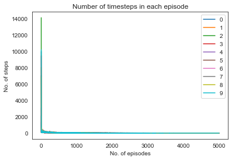

```python
for i in range(len(attempts_sarsamax)):
    steps_arr=attempts_sarsamax[i][1]
    n_episodes=attempts_sarsamax[i][4]
    plt.plot(range(5000),steps_arr)
    plt.xlabel('No. of episodes')
    plt.ylabel('No. of steps')
    plt.title('Number of timesteps in each episode')
    plt.legend(np.arange(i+1))
plt.show()
```

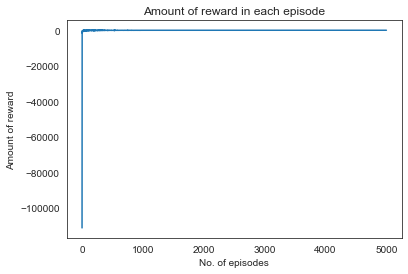

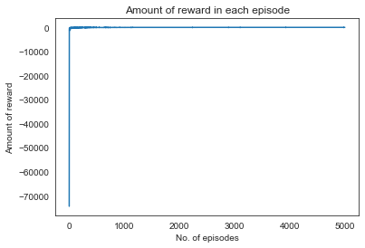

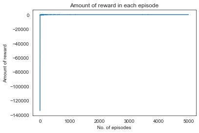

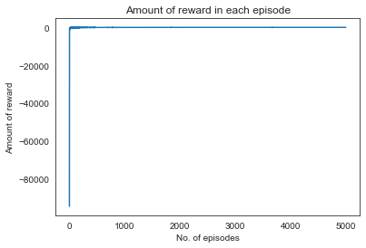

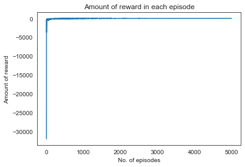

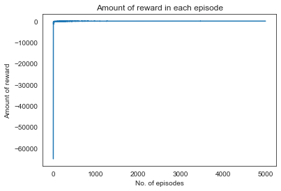

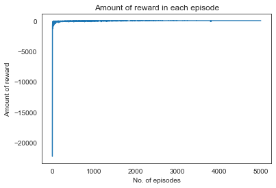

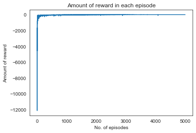

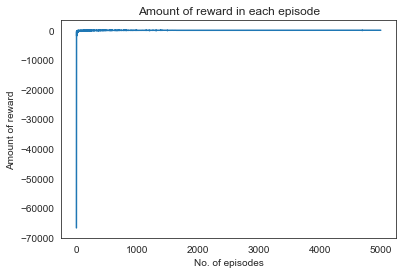

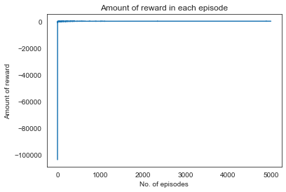

```python
for i in range(len(attempts_sarsamax)):
    reward=attempts_sarsamax[i][2]
    n_episodes=attempts_sarsamax[i][4]
    plt.plot(range(5000),reward)
    plt.xlabel('No. of episodes')
    plt.ylabel('Amount of reward')
    plt.title('Amount of reward in each episode')
    plt.show()
```